# Intervaly spolehlivosti: Cvičení Řešení

Kateřina Večerková vecerkok@vscht.cz

2025-07-03

# Cvičení

## **Cvičení 1: Interval spolehlivosti pro průměr (velký vzorek, Z-statistika)**

1. Máte vzorek 50 náhodně vygenerovaných hodnot z normálního rozdělení se střední hodnotou 65 a směrodatnou odchylkou 10. Vypočítejte 95% interval spolehlivosti pro průměr pomocí Z-statistiky (předpokládejte n > 30).

```r
set.seed(123)
sample_data <- rnorm(50, mean = 65, sd = 10)

# Calculate 95% CI using Z-statistic

sample_data_mean <- mean(sample_data)
sample_data_sd <- sd(sample_data)

print(sample_data_mean)
```

```
## [1] 65.34404
```

```r
sample_data_mean - qnorm(0.975) * sample_data_sd/sqrt(50)
```

```
## [1] 62.7777
```

```r
sample_data_mean + qnorm(0.975) * sample_data_sd/sqrt(50)
```

```
## [1] 67.91037
```

## **Cvičení 2: Interval spolehlivosti pro průměr (malý vzorek, t-statistika)**

2. Máte malý vzorek 15 měření z populace s neznámou střední hodnotou a směrodatnou odchylkou. Hodnoty vzorku jsou: `c(12, 15, 14, 11, 15, 18, 16, 14, 13, 19, 21, 16, 14, 12, 20)`. Vypočítejte 95% interval spolehlivosti pro průměr pomocí t-statistiky (protože n < 30).

```r
sample_data <- c(12, 15, 14, 11, 15, 18, 16, 14, 13, 19, 21, 16, 14, 12, 20)

# Calculate 95% CI using t-statistic

t.test(sample_data)$conf.int
```

```
## [1] 13.66322 17.00345
## attr(,"conf.level")
## [1] 0.95
```

## **Cvičení 3: Vliv velikosti vzorku na interval spolehlivosti**

3. Vygenerujte dva vzorky — jeden o velikosti 20 a druhý o velikosti 100 — z normálního rozdělení se střední hodnotou 50 a směrodatnou odchylkou 8. Vypočítejte 95% interval spolehlivosti pro průměr obou vzorků. Porovnejte šířky obou intervalů a vysvětlete, jak velikost vzorku ovlivňuje šířku intervalu.

```r
set.seed(456)
sample_20 <- rnorm(20, mean = 50, sd = 8)
sample_100 <- rnorm(100, mean = 50, sd = 8)

# Calculate 95% CI for both sample_20 and sample_100

t.test(sample_20)$conf.int
```

```
## [1] 49.52971 58.19863
## attr(,"conf.level")
## [1] 0.95
```

```r
sample_100_mean <- mean(sample_100)
sample_100_sd <- sd(sample_100)

print(sample_100_mean - qnorm(0.975) * (sample_100_sd / sqrt(100)))
```

```
## [1] 48.54418
```

```r
print(sample_100_mean + qnorm(0.975) * (sample_100_sd / sqrt(100)))
```

```
## [1] 51.48336
```

## **Cvičení 4: Vizualizace intervalů spolehlivosti pomocí ggplot2**

4. Použijte vzorek 100 datových bodů vygenerovaných z normálního rozdělení (průměr = 70, sd = 12). Vygenerujte 1000 bootstrapovaných průměrů a vytvořte histogram. Vykreslete 95% interval spolehlivosti těchto průměrů na histogram pomocí `ggplot2`.

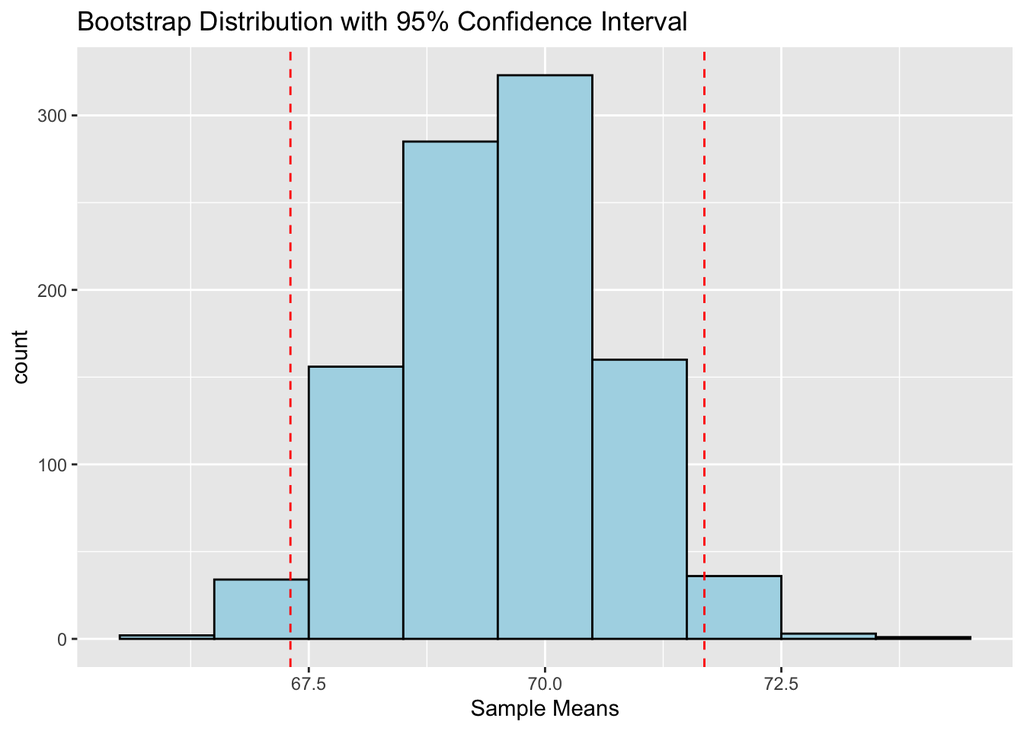

```r
library(ggplot2)
set.seed(789)
sample_data <- rnorm(100, mean = 70, sd = 12)

# Bootstrap and plot 95% CI for the means

boot_means <- replicate(1000, mean(sample(sample_data, size = 100, replace = TRUE)))
ci <- quantile(boot_means, c(0.025, 0.975))

# Visualizing CI
ggplot(data.frame(x = boot_means), aes(x = x)) +
 geom_histogram(binwidth = 1, fill = "lightblue", color = "black") +
 geom_vline(xintercept = ci, color = "red", linetype = "dashed") +
 labs(title = "Bootstrap Distribution with 95% Confidence Interval", x = "Sample Means")
```

## **Cvičení 5: Interpretace intervalů spolehlivosti**

5. Vypočítali jste 95% interval spolehlivosti pro průměr datové sady a získali jste interval [40.5, 49.5].
   1. Interpretujte tento výsledek v kontextu intervalů spolehlivosti.
   2. Pokud zvýšíte úroveň spolehlivosti na 99 %, co očekáváte, že se stane se šířkou intervalu?

```r
# a. We can be 95% confident, that the population mean lies somewhere in the range [40.5, 49.5].
# b. The width would increase. If we want higher confidence, then we need to cover wider range.
```

## **Cvičení 6: Výpočet intervalů spolehlivosti pomocí vestavěné funkce**

6. Použijte vestavěnou funkci `t.test()` v R pro výpočet intervalu spolehlivosti pro následující datovou sadu: `c(5.1, 5.4, 5.9, 6.2, 5.8, 5.7, 6.1, 5.6, 5.5, 6.3)`. Vypočítejte 99% interval spolehlivosti pro průměr těchto dat.

```r
data <- c(5.1, 5.4, 5.9, 6.2, 5.8, 5.7, 6.1, 5.6, 5.5, 6.3)

# Calculate 99% CI using t.test()

t.test(data, conf.level=0.99)$conf.int
```

```
## [1] 5.371829 6.148171
## attr(,"conf.level")
## [1] 0.99
```